# Classification Analysis: Airline Passenger Satisfaction

DSC532 Group Project

2026-03-27

# 1 Setup and Libraries

```r
# Install packages if needed (uncomment on first run)
# install.packages(c("tidyverse", "janitor", "skimr", "corrplot", "caret",
#                     "MASS", "class", "e1071", "glmnet", "pROC",
#                     "knitr", "kableExtra", "gridExtra", "boot"))

library(tidyverse)
library(janitor)
library(skimr)
library(corrplot)
library(caret)
library(MASS)
library(pROC)
library(knitr)
library(kableExtra)
library(gridExtra)
library(boot)

set.seed(42)
```

# 2 Data Loading and Overview

The dataset contains airline passenger satisfaction survey responses. We load the pre-split training and test sets separately to preserve the integrity of the evaluation pipeline — the test set will not be touched until the final model evaluation.

```r
train_raw <- read_csv("train.csv")
test_raw  <- read_csv("test.csv")

cat("Training set dimensions:", dim(train_raw), "\n")
```

```
## Training set dimensions: 103904 25
```

```r
cat("Test set dimensions:", dim(test_raw), "\n")
```

```
## Test set dimensions: 25976 25
```

```r
glimpse(train_raw)
```

```
## Rows: 103,904
## Columns: 25
## $ ...1                                <dbl> 0, 1, 2, 3, 4, 5, 6, 7, 8, 9, 10, …
## $ id                                  <dbl> 70172, 5047, 110028, 24026, 119299…
## $ Gender                              <chr> "Male", "Male", "Female", "Female"…
## $ `Customer Type`                     <chr> "Loyal Customer", "disloyal Custom…
## $ Age                                 <dbl> 13, 25, 26, 25, 61, 26, 47, 52, 41…
## $ `Type of Travel`                    <chr> "Personal Travel", "Business trave…
## $ Class                               <chr> "Eco Plus", "Business", "Business"…
## $ `Flight Distance`                   <dbl> 460, 235, 1142, 562, 214, 1180, 12…
## $ `Inflight wifi service`             <dbl> 3, 3, 2, 2, 3, 3, 2, 4, 1, 3, 4, 2…
## $ `Departure/Arrival time convenient` <dbl> 4, 2, 2, 5, 3, 4, 4, 3, 2, 3, 5, 4…
## $ `Ease of Online booking`            <dbl> 3, 3, 2, 5, 3, 2, 2, 4, 2, 3, 5, 2…
## $ `Gate location`                     <dbl> 1, 3, 2, 5, 3, 1, 3, 4, 2, 4, 4, 2…
## $ `Food and drink`                    <dbl> 5, 1, 5, 2, 4, 1, 2, 5, 4, 2, 2, 1…
## $ `Online boarding`                   <dbl> 3, 3, 5, 2, 5, 2, 2, 5, 3, 3, 5, 2…
## $ `Seat comfort`                      <dbl> 5, 1, 5, 2, 5, 1, 2, 5, 3, 3, 2, 1…
## $ `Inflight entertainment`            <dbl> 5, 1, 5, 2, 3, 1, 2, 5, 1, 2, 2, 1…
## $ `On-board service`                  <dbl> 4, 1, 4, 2, 3, 3, 3, 5, 1, 2, 3, 1…
## $ `Leg room service`                  <dbl> 3, 5, 3, 5, 4, 4, 3, 5, 2, 3, 3, 2…
## $ `Baggage handling`                  <dbl> 4, 3, 4, 3, 4, 4, 4, 5, 1, 4, 5, 5…
## $ `Checkin service`                   <dbl> 4, 1, 4, 1, 3, 4, 3, 4, 4, 4, 3, 5…
## $ `Inflight service`                  <dbl> 5, 4, 4, 4, 3, 4, 5, 5, 1, 3, 5, 5…
## $ Cleanliness                         <dbl> 5, 1, 5, 2, 3, 1, 2, 4, 2, 2, 2, 1…
## $ `Departure Delay in Minutes`        <dbl> 25, 1, 0, 11, 0, 0, 9, 4, 0, 0, 0,…
## $ `Arrival Delay in Minutes`          <dbl> 18, 6, 0, 9, 0, 0, 23, 0, 0, 0, 0,…
## $ satisfaction                        <chr> "neutral or dissatisfied", "neutra…
```

```r
head(train_raw)
```

```
## # A tibble: 6 × 25
##    ...1     id Gender `Customer Type`     Age `Type of Travel` Class
##   <dbl>  <dbl> <chr>  <chr>             <dbl> <chr>            <chr>
## 1     0  70172 Male   Loyal Customer       13 Personal Travel  Eco Plus
## 2     1   5047 Male   disloyal Customer    25 Business travel  Business
## 3     2 110028 Female Loyal Customer       26 Business travel  Business
## 4     3  24026 Female Loyal Customer       25 Business travel  Business
## 5     4 119299 Male   Loyal Customer       61 Business travel  Business
## 6     5 111157 Female Loyal Customer       26 Personal Travel  Eco
## # ℹ 18 more variables: `Flight Distance` <dbl>, `Inflight wifi service` <dbl>,
## #   `Departure/Arrival time convenient` <dbl>, `Ease of Online booking` <dbl>,
## #   `Gate location` <dbl>, `Food and drink` <dbl>, `Online boarding` <dbl>,
## #   `Seat comfort` <dbl>, `Inflight entertainment` <dbl>,
## #   `On-board service` <dbl>, `Leg room service` <dbl>,
## #   `Baggage handling` <dbl>, `Checkin service` <dbl>,
## #   `Inflight service` <dbl>, Cleanliness <dbl>, …
```

```r
summary(train_raw)
```

```
##       ...1              id            Gender          Customer Type
##  Min.   :     0   Min.   :     1   Length:103904      Length:103904
##  1st Qu.: 25976   1st Qu.: 32534   Class :character   Class :character
##  Median : 51952   Median : 64857   Mode  :character   Mode  :character
##  Mean   : 51952   Mean   : 64924
##  3rd Qu.: 77927   3rd Qu.: 97368
##  Max.   :103903   Max.   :129880
##
##       Age        Type of Travel        Class           Flight Distance
##  Min.   : 7.00   Length:103904      Length:103904      Min.   :  31
##  1st Qu.:27.00   Class :character   Class :character   1st Qu.: 414
##  Median :40.00   Mode  :character   Mode  :character   Median : 843
##  Mean   :39.38                                         Mean   :1189
##  3rd Qu.:51.00                                         3rd Qu.:1743
##  Max.   :85.00                                         Max.   :4983
##
##  Inflight wifi service Departure/Arrival time convenient Ease of Online booking
##  Min.   :0.00          Min.   :0.00                      Min.   :0.000
##  1st Qu.:2.00          1st Qu.:2.00                      1st Qu.:2.000
##  Median :3.00          Median :3.00                      Median :3.000
##  Mean   :2.73          Mean   :3.06                      Mean   :2.757
##  3rd Qu.:4.00          3rd Qu.:4.00                      3rd Qu.:4.000
##  Max.   :5.00          Max.   :5.00                      Max.   :5.000
##
##  Gate location   Food and drink  Online boarding  Seat comfort
##  Min.   :0.000   Min.   :0.000   Min.   :0.00    Min.   :0.000
##  1st Qu.:2.000   1st Qu.:2.000   1st Qu.:2.00    1st Qu.:2.000
##  Median :3.000   Median :3.000   Median :3.00    Median :4.000
##  Mean   :2.977   Mean   :3.202   Mean   :3.25    Mean   :3.439
##  3rd Qu.:4.000   3rd Qu.:4.000   3rd Qu.:4.00    3rd Qu.:5.000
##  Max.   :5.000   Max.   :5.000   Max.   :5.00    Max.   :5.000
##
##  Inflight entertainment On-board service Leg room service Baggage handling
##  Min.   :0.000          Min.   :0.000    Min.   :0.000    Min.   :1.000
##  1st Qu.:2.000          1st Qu.:2.000    1st Qu.:2.000    1st Qu.:3.000
##  Median :4.000          Median :4.000    Median :4.000    Median :4.000
##  Mean   :3.358          Mean   :3.382    Mean   :3.351    Mean   :3.632
##  3rd Qu.:4.000          3rd Qu.:4.000    3rd Qu.:4.000    3rd Qu.:5.000
##  Max.   :5.000          Max.   :5.000    Max.   :5.000    Max.   :5.000
##
##  Checkin service Inflight service  Cleanliness    Departure Delay in Minutes
##  Min.   :0.000   Min.   :0.00     Min.   :0.000   Min.   :   0.00
##  1st Qu.:3.000   1st Qu.:3.00     1st Qu.:2.000   1st Qu.:   0.00
##  Median :3.000   Median :4.00     Median :3.000   Median :   0.00
##  Mean   :3.304   Mean   :3.64     Mean   :3.286   Mean   :  14.82
##  3rd Qu.:4.000   3rd Qu.:5.00     3rd Qu.:4.000   3rd Qu.:  12.00
##  Max.   :5.000   Max.   :5.00     Max.   :5.000   Max.   :1592.00
##
##  Arrival Delay in Minutes satisfaction
##  Min.   :   0.00          Length:103904
##  1st Qu.:   0.00          Class :character
##  Median :   0.00          Mode  :character
##  Mean   :  15.18
##  3rd Qu.:  13.00
##  Max.   :1584.00
##  NA's   :310
```

The training set has 103904 observations and 25 variables. The first two columns (`...1` and `id`) are administrative identifiers with no predictive value. The target variable `satisfaction` is binary: “satisfied” or “neutral or dissatisfied”.

# 3 Data Cleaning

## 3.1 Removing Identifiers and Standardising Column Names

We remove the unnamed index column (`...1`) and the `id` column since they carry no predictive information, and apply `clean_names()` to ensure consistent snake_case naming throughout the analysis.

```r
train_clean <- train_raw %>%
  clean_names() %>%
  dplyr::select(-any_of(c("x1", "x_1")), -id)

test_clean <- test_raw %>%
  clean_names() %>%
  dplyr::select(-any_of(c("x1", "x_1")), -id)

colnames(train_clean)
```

```
##  [1] "gender"                            "customer_type"
##  [3] "age"                               "type_of_travel"
##  [5] "class"                             "flight_distance"
##  [7] "inflight_wifi_service"             "departure_arrival_time_convenient"
##  [9] "ease_of_online_booking"            "gate_location"
## [11] "food_and_drink"                    "online_boarding"
## [13] "seat_comfort"                      "inflight_entertainment"
## [15] "on_board_service"                  "leg_room_service"
## [17] "baggage_handling"                  "checkin_service"
## [19] "inflight_service"                  "cleanliness"
## [21] "departure_delay_in_minutes"        "arrival_delay_in_minutes"
## [23] "satisfaction"
```

After cleaning we have 23 variables: 4 continuous (age, flight distance, departure delay, arrival delay), 14 ordinal service ratings (1–5 scale), and 4 categorical variables (gender, customer type, type of travel, class), plus the target.

## 3.2 Missing Values Analysis

```r
bind_rows(
  train_clean %>%
    summarise(across(everything(), ~ sum(is.na(.)))) %>%
    pivot_longer(everything(), names_to = "variable", values_to = "na_count") %>%
    mutate(dataset = "train", na_percent = round(na_count / nrow(train_clean) * 100, 3)),

  test_clean %>%
    summarise(across(everything(), ~ sum(is.na(.)))) %>%
    pivot_longer(everything(), names_to = "variable", values_to = "na_count") %>%
    mutate(dataset = "test", na_percent = round(na_count / nrow(test_clean) * 100, 3))
) %>%
  filter(na_count > 0) %>%
  dplyr::select(dataset, variable, na_count, na_percent) %>%
  arrange(desc(na_count)) %>%
  kable(col.names = c("Dataset", "Variable", "Missing Count", "Missing %")) %>%
  kable_styling(bootstrap_options = "striped", full_width = FALSE)
```

| Dataset | Variable | Missing Count | Missing % |
| --- | --- | --- | --- |
| train | arrival_delay_in_minutes | 310 | 0.298 |
| test | arrival_delay_in_minutes | 83 | 0.320 |

Missing values are present exclusively in `arrival_delay_in_minutes` — roughly 0.3% of both the training and test sets. This low proportion rules out systematic dropout but we still need a principled imputation strategy rather than simple deletion. Before deciding on an approach, we conduct a thorough EDA to understand the structure of the data and the relationships between all variables — in particular with `arrival_delay_in_minutes`.

# 4 Exploratory Data Analysis

The goal of EDA is threefold: (1) understand the distributions of individual variables and their relationship with the target, (2) identify any data quality issues, and (3) gather the evidence needed to justify our imputation strategy for the missing arrival delay values.

## 4.1 Target Variable Distribution

```r
train_clean %>%
  count(satisfaction) %>%
  mutate(prop = round(n / sum(n) * 100, 1)) %>%
  kable(col.names = c("Class", "Count", "Percentage (%)")) %>%
  kable_styling(bootstrap_options = "striped", full_width = FALSE)
```

| Class | Count | Percentage (%) |
| --- | --- | --- |
| neutral or dissatisfied | 58879 | 56.7 |
| satisfied | 45025 | 43.3 |

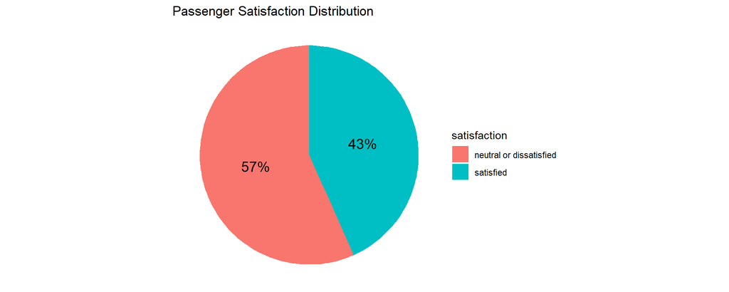

```r
train_clean %>%
  count(satisfaction) %>%
  mutate(percent = n / sum(n),
         label = scales::percent(percent)) %>%
  ggplot(aes(x = "", y = n, fill = satisfaction)) +
  geom_col(width = 1) +
  coord_polar(theta = "y") +
  geom_text(aes(label = label), position = position_stack(vjust = 0.5), size = 5) +
  labs(title = "Passenger Satisfaction Distribution") +
  theme_void()
```

The dataset exhibits a moderate class imbalance: approximately 56.7% of passengers are neutral or dissatisfied and 43.3% are satisfied. This imbalance is not severe enough to require resampling techniques, but it means raw accuracy can be misleading — we will prioritise F1 score, precision, recall, and AUC when comparing models.

## 4.2 Distributions of Continuous Variables

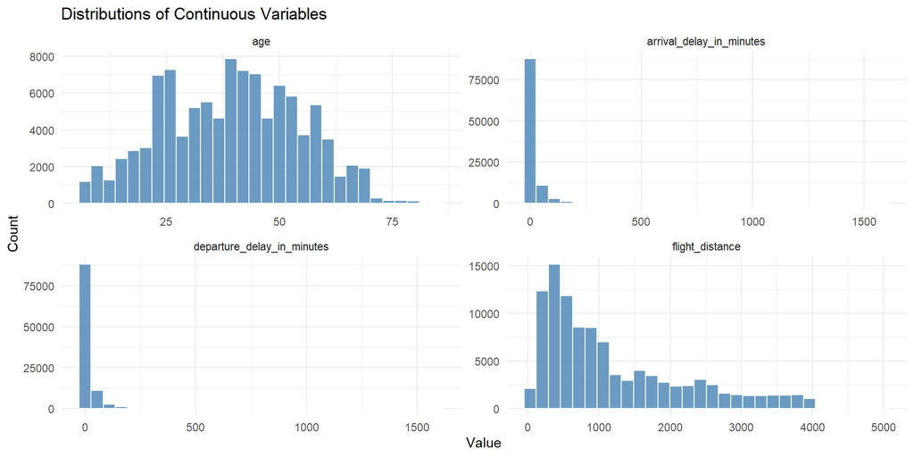

```r
train_clean %>%
  dplyr::select(age, flight_distance,
                departure_delay_in_minutes, arrival_delay_in_minutes) %>%
  pivot_longer(everything(), names_to = "variable", values_to = "value") %>%
  ggplot(aes(x = value)) +
  geom_histogram(bins = 30, fill = "steelblue", color = "white", alpha = 0.8) +
  facet_wrap(~ variable, scales = "free", ncol = 2) +
  labs(title = "Distributions of Continuous Variables",
       x = "Value", y = "Count") +
  theme_minimal()
```

**Age** is moderately spread across adults, with a slight bimodal pattern suggesting two main passenger age groups.

**Flight distance** is right-skewed, with the majority of flights being short-to-medium haul and a long upper tail likely for intercontinental routes.

**Departure and arrival delay** are both heavily right-skewed with a mass of near-zero values and a sparse but long upper tail. These will be examined in detail in the outlier analysis below.

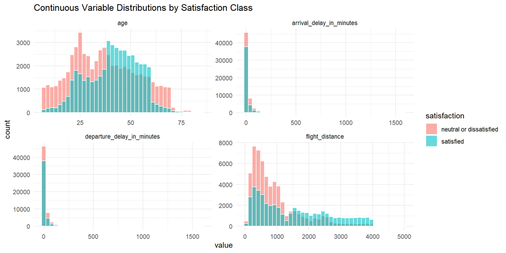

```r
train_clean %>%
  dplyr::select(satisfaction, age, flight_distance,
                departure_delay_in_minutes, arrival_delay_in_minutes) %>%
  pivot_longer(cols = -satisfaction, names_to = "variable", values_to = "value") %>%
  ggplot(aes(x = value, fill = satisfaction)) +
  geom_histogram(bins = 40, color = "white", alpha = 0.6, position = "identity") +
  facet_wrap(~ variable, scales = "free", ncol = 2) +
  labs(title = "Continuous Variable Distributions by Satisfaction Class") +
  theme_minimal()
```

Breaking the distributions down by satisfaction class reveals two notable patterns. First, satisfied passengers tend to be somewhat older, with the satisfied distribution shifted towards middle age. Second, satisfied passengers are more heavily concentrated among longer flights, suggesting that business travellers (who tend to fly further) drive satisfaction. Departure and arrival delays do not show a strong visual separation by class, which is consistent with the finding that most passengers experience little to no delay.

### 4.2.1 Delay Distribution Analysis

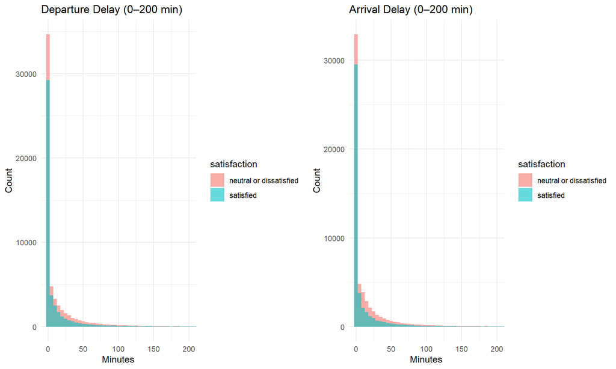

```r
p_dep <- train_clean %>%
  ggplot(aes(x = departure_delay_in_minutes, fill = satisfaction)) +
  geom_histogram(binwidth = 5, alpha = 0.6, position = "identity") +
  coord_cartesian(xlim = c(0, 200)) +
  labs(title = "Departure Delay (0–200 min)", x = "Minutes", y = "Count") +
  theme_minimal()

p_arr <- train_clean %>%
  ggplot(aes(x = arrival_delay_in_minutes, fill = satisfaction)) +
  geom_histogram(binwidth = 5, alpha = 0.6, position = "identity") +
  coord_cartesian(xlim = c(0, 200)) +
  labs(title = "Arrival Delay (0–200 min)", x = "Minutes", y = "Count") +
  theme_minimal()

grid.arrange(p_dep, p_arr, ncol = 2)
```

Both delay variables have extreme right tails. We investigate whether the very high values are genuine extreme events or data entry errors.

### 4.2.2 Delay Outlier Investigation

```r
train_clean %>%
  dplyr::select(departure_delay_in_minutes, arrival_delay_in_minutes) %>%
  summarise(across(everything(), list(
    min    = ~ min(., na.rm = TRUE),
    p25    = ~ quantile(., 0.25, na.rm = TRUE),
    median = ~ median(., na.rm = TRUE),
    p75    = ~ quantile(., 0.75, na.rm = TRUE),
    p95    = ~ quantile(., 0.95, na.rm = TRUE),
    p99    = ~ quantile(., 0.99, na.rm = TRUE),
    max    = ~ max(., na.rm = TRUE)
  ))) %>%
  pivot_longer(everything(), names_to = c("variable", "stat"),
               names_sep = "_(?=[^_]+$)") %>%
  pivot_wider(names_from = stat, values_from = value) %>%
  kable(digits = 1) %>%
  kable_styling(bootstrap_options = "striped", full_width = FALSE)
```

| variable | min | p25 | median | p75 | p95 | p99 | max |
| --- | --- | --- | --- | --- | --- | --- | --- |
| departure_delay_in_minutes | 0 | 0 | 0 | 12 | 78 | 182 | 1592 |
| arrival_delay_in_minutes | 0 | 0 | 0 | 13 | 79 | 184 | 1584 |

```r
train_clean %>%
  summarise(
    dep_over_180  = sum(departure_delay_in_minutes > 180, na.rm = TRUE),
    dep_over_300  = sum(departure_delay_in_minutes > 300, na.rm = TRUE),
    dep_over_500  = sum(departure_delay_in_minutes > 500, na.rm = TRUE),
    arr_over_180  = sum(arrival_delay_in_minutes > 180, na.rm = TRUE),
    arr_over_300  = sum(arrival_delay_in_minutes > 300, na.rm = TRUE),
    arr_over_500  = sum(arrival_delay_in_minutes > 500, na.rm = TRUE)
  ) %>%
  kable() %>%
  kable_styling(bootstrap_options = "striped", full_width = FALSE)
```

| dep_over_180 | dep_over_300 | dep_over_500 | arr_over_180 | arr_over_300 | arr_over_500 |
| --- | --- | --- | --- | --- | --- |
| 1055 | 247 | 32 | 1081 | 255 | 31 |

```r
train_clean %>%
  filter(departure_delay_in_minutes > 500) %>%
  dplyr::select(departure_delay_in_minutes, arrival_delay_in_minutes,
                flight_distance, class, type_of_travel,
                departure_arrival_time_convenient) %>%
  arrange(desc(departure_delay_in_minutes))
```

```
## # A tibble: 32 × 6
##    departure_delay_in_minutes arrival_delay_in_minutes flight_distance class
##                         <dbl>                    <dbl>           <dbl> <chr>
##  1                       1592                     1584            1120 Eco
##  2                       1305                     1280            2916 Business
##  3                       1017                     1011            1959 Business
##  4                        978                      970            1598 Eco
##  5                        933                      920            2187 Business
##  6                        930                      952            2418 Business
##  7                        921                      924             577 Business
##  8                        859                      860            1746 Business
##  9                        853                      823            3979 Business
## 10                        750                      729             998 Eco
## # ℹ 22 more rows
## # ℹ 2 more variables: type_of_travel <chr>,
## #   departure_arrival_time_convenient <dbl>
```

Inspecting the extreme cases confirms that very long departure delays are always accompanied by comparably long arrival delays — the two variables move in lockstep. Delays exceeding 500 minutes (over 8 hours) are operationally plausible and can occur in practice due to severe weather, mechanical failures, or flight rescheduling to the following day. We therefore retain these observations, as removing them would introduce selection bias and prevent our models from generalising to such rare but real scenarios.

## 4.3 Flight Distance Outlier Analysis

```r
train_clean %>%
  dplyr::select(flight_distance) %>%
  summarise(across(everything(), list(
    min    = ~ min(., na.rm = TRUE),
    p25    = ~ quantile(., 0.25, na.rm = TRUE),
    median = ~ median(., na.rm = TRUE),
    p75    = ~ quantile(., 0.75, na.rm = TRUE),
    p95    = ~ quantile(., 0.95, na.rm = TRUE),
    p99    = ~ quantile(., 0.99, na.rm = TRUE),
    max    = ~ max(., na.rm = TRUE)
  ))) %>%
  pivot_longer(everything(),
               names_to = c("variable", "stat"),
               names_sep = "_(?=[^_]+$)") %>%
  pivot_wider(names_from = stat, values_from = value) %>%
  kable(digits = 1) %>%
  kable_styling(bootstrap_options = "striped", full_width = FALSE)
```

| variable | min | p25 | median | p75 | p95 | p99 | max |
| --- | --- | --- | --- | --- | --- | --- | --- |
| flight_distance | 31 | 414 | 843 | 1743 | 3383 | 3882 | 4983 |

While the upper tail of `flight_distance` reaches approximately 4,983 miles, this is entirely consistent with long-haul intercontinental routes. No implausible values were identified and no observations are removed.

## 4.4 Service Rating Distributions

The 14 service attributes are measured on a discrete 1–5 scale (with 0 occasionally representing “not applicable”).

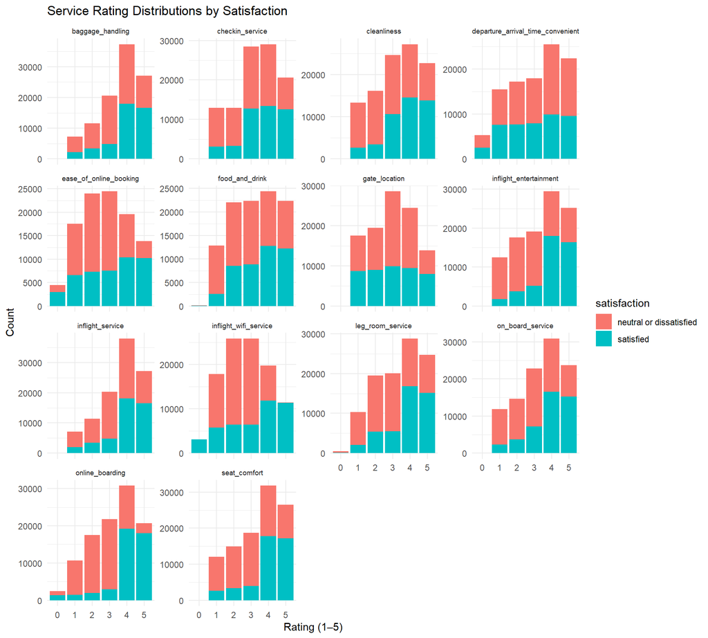

```r
rating_vars <- c("inflight_wifi_service", "departure_arrival_time_convenient",
                  "ease_of_online_booking", "gate_location", "food_and_drink",
                  "online_boarding", "seat_comfort", "inflight_entertainment",
                  "on_board_service", "leg_room_service", "baggage_handling",
                  "checkin_service", "inflight_service", "cleanliness")

train_clean %>%
  dplyr::select(satisfaction, all_of(rating_vars)) %>%
  pivot_longer(cols = -satisfaction, names_to = "variable", values_to = "value") %>%
  ggplot(aes(x = factor(value), fill = satisfaction)) +
  geom_bar(position = "stack") +
  facet_wrap(~ variable, scales = "free_y", ncol = 4) +
  labs(title = "Service Rating Distributions by Satisfaction",
       x = "Rating (1–5)", y = "Count") +
  theme_minimal() +
  theme(strip.text = element_text(size = 7))
```

Most service attributes concentrate in the 3–4 range, reflecting a broadly moderate to positive perception of airline services. Notably, variables such as `inflight_entertainment`, `seat_comfort`, and `online_boarding` show a clearer split between the two satisfaction classes at the higher rating values — passengers rating these services as 4 or 5 are predominantly satisfied. Variables like `gate_location` and `departure_arrival_time_convenient` show less separation, suggesting they are weaker predictors of overall satisfaction.

## 4.5 Satisfaction by Key Categorical Variables

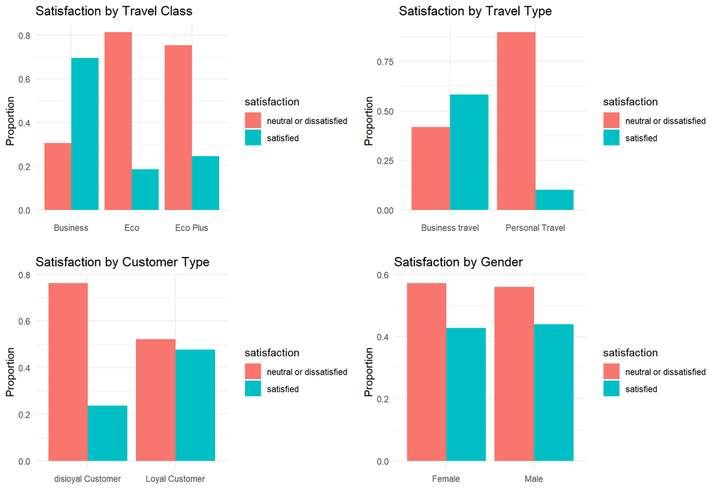

```r
p1 <- train_clean %>%
  count(class, satisfaction) %>%
  group_by(class) %>%
  mutate(prop = n / sum(n)) %>%
  ggplot(aes(x = class, y = prop, fill = satisfaction)) +
  geom_col(position = "dodge") +
  labs(title = "Satisfaction by Travel Class", y = "Proportion", x = "") +
  theme_minimal()

p2 <- train_clean %>%
  count(type_of_travel, satisfaction) %>%
  group_by(type_of_travel) %>%
  mutate(prop = n / sum(n)) %>%
  ggplot(aes(x = type_of_travel, y = prop, fill = satisfaction)) +
  geom_col(position = "dodge") +
  labs(title = "Satisfaction by Travel Type", y = "Proportion", x = "") +
  theme_minimal()

p3 <- train_clean %>%
  count(customer_type, satisfaction) %>%
  group_by(customer_type) %>%
  mutate(prop = n / sum(n)) %>%
  ggplot(aes(x = customer_type, y = prop, fill = satisfaction)) +
  geom_col(position = "dodge") +
  labs(title = "Satisfaction by Customer Type", y = "Proportion", x = "") +
  theme_minimal()

p4 <- train_clean %>%
  count(gender, satisfaction) %>%
  group_by(gender) %>%
  mutate(prop = n / sum(n)) %>%
  ggplot(aes(x = gender, y = prop, fill = satisfaction)) +
  geom_col(position = "dodge") +
  labs(title = "Satisfaction by Gender", y = "Proportion", x = "") +
  theme_minimal()

grid.arrange(p1, p2, p3, p4, ncol = 2)
```

The categorical variables reveal several strong patterns. Business class passengers are the most satisfied group by a wide margin, while Economy and Eco Plus passengers are predominantly dissatisfied — suggesting that cabin class is one of the strongest predictors in the dataset. Similarly, passengers travelling for business purposes show much higher satisfaction than those travelling for personal reasons. Loyal customers are more satisfied than disloyal customers, possibly because loyalty status correlates with business travel and premium cabin access. Gender shows only a negligible difference in satisfaction rates.

## 4.6 Correlation Analysis

### 4.6.1 Correlation Heatmap

```r
train_clean_num <- train_clean %>%
  mutate(satisfaction_num = ifelse(satisfaction == "satisfied", 1, 0)) %>%
  dplyr::select(where(is.numeric))

cor_mat <- cor(train_clean_num, use = "pairwise.complete.obs")
round(cor_mat, 2)
```

```
##                                     age flight_distance inflight_wifi_service
## age                                1.00            0.10                  0.02
## flight_distance                    0.10            1.00                  0.01
## inflight_wifi_service              0.02            0.01                  1.00
## departure_arrival_time_convenient  0.04           -0.02                  0.34
## ease_of_online_booking             0.02            0.07                  0.72
## gate_location                      0.00            0.00                  0.34
## food_and_drink                     0.02            0.06                  0.13
## online_boarding                    0.21            0.21                  0.46
## seat_comfort                       0.16            0.16                  0.12
## inflight_entertainment             0.08            0.13                  0.21
## on_board_service                   0.06            0.11                  0.12
## leg_room_service                   0.04            0.13                  0.16
## baggage_handling                  -0.05            0.06                  0.12
## checkin_service                    0.04            0.07                  0.04
## inflight_service                  -0.05            0.06                  0.11
## cleanliness                        0.05            0.09                  0.13
## departure_delay_in_minutes        -0.01            0.00                 -0.02
## arrival_delay_in_minutes          -0.01            0.00                 -0.02
## satisfaction_num                   0.14            0.30                  0.28
##                                   departure_arrival_time_convenient
## age                                                            0.04
## flight_distance                                               -0.02
## inflight_wifi_service                                          0.34
## departure_arrival_time_convenient                              1.00
## ease_of_online_booking                                         0.44
## gate_location                                                  0.44
## food_and_drink                                                 0.00
## online_boarding                                                0.07
## seat_comfort                                                   0.01
## inflight_entertainment                                         0.00
## on_board_service                                               0.07
## leg_room_service                                               0.01
## baggage_handling                                               0.07
## checkin_service                                                0.09
## inflight_service                                               0.07
## cleanliness                                                    0.01
## departure_delay_in_minutes                                     0.00
## arrival_delay_in_minutes                                       0.00
## satisfaction_num                                              -0.05
```

[output cut: 125 more lines]

```
## ease_of_online_booking                               -0.01             0.17
## gate_location                                         0.01             0.00
## food_and_drink                                       -0.03             0.21
## online_boarding                                      -0.02             0.50
## seat_comfort                                         -0.03             0.35
## inflight_entertainment                               -0.03             0.40
## on_board_service                                     -0.04             0.32
## leg_room_service                                      0.01             0.31
## baggage_handling                                     -0.01             0.25
## checkin_service                                      -0.02             0.24
## inflight_service                                     -0.06             0.24
## cleanliness                                          -0.02             0.31
## departure_delay_in_minutes                            0.97            -0.05
## arrival_delay_in_minutes                              1.00            -0.06
## satisfaction_num                                     -0.06             1.00
```

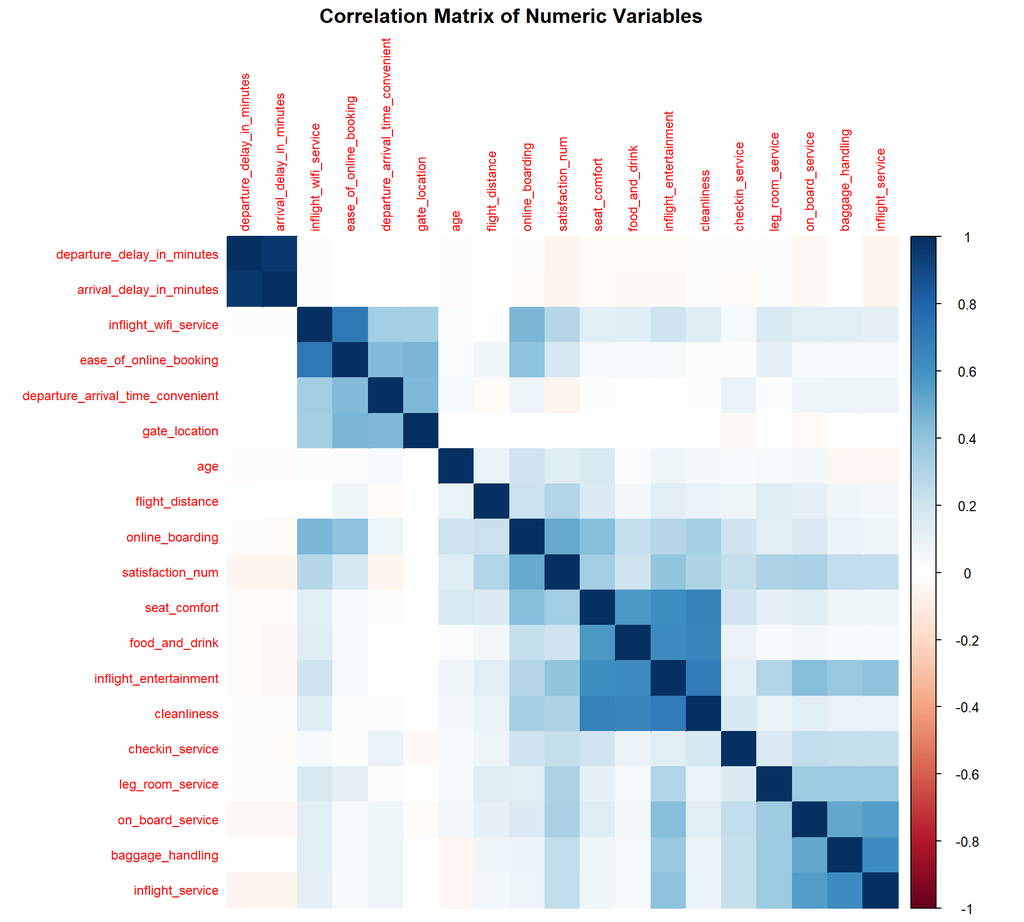

```r
corrplot(cor_mat,
         method = "color",
         order = "hclust",
         number.cex = 0.55,
         tl.cex = 0.75,
         title = "Correlation Matrix of Numeric Variables",
         mar = c(0, 0, 1.5, 0))
```

Note: interpreting the correlation of binary variables (like `satisfaction_num`) with continuous predictors should be done with caution, as Pearson correlation assumes linearity and does not capture threshold or interaction effects.

## 4.7 Arrival Delay: Justifying the Imputation Strategy

Before imputing the ~0.3% of missing `arrival_delay_in_minutes` values, we systematically examine its relationship with every other variable. The goal is to determine the minimal sufficient predictor set for the imputation model.

### 4.7.1 Relationship with Numeric Variables

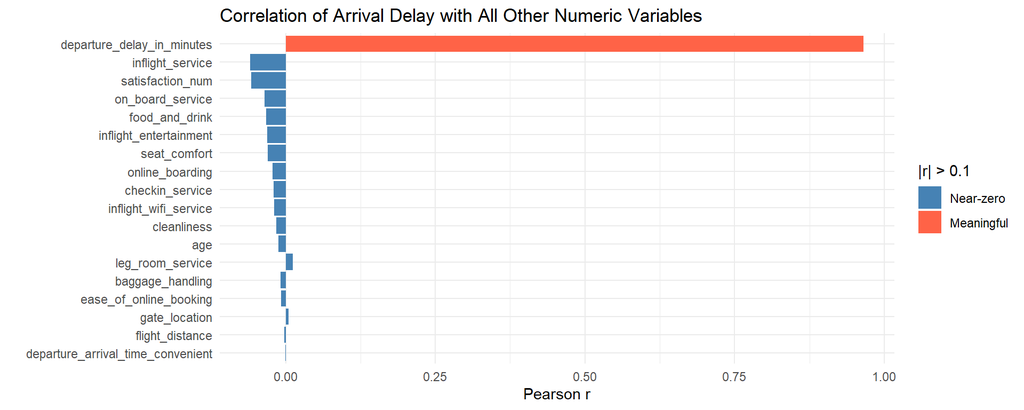

```r
arr_cors <- cor_mat["arrival_delay_in_minutes", ]
arr_cors_df <- data.frame(
  variable = names(arr_cors),
  correlation = arr_cors
) %>%
  filter(variable != "arrival_delay_in_minutes") %>%
  arrange(abs(correlation))

ggplot(arr_cors_df, aes(x = reorder(variable, abs(correlation)),
                        y = correlation, fill = abs(correlation) > 0.1)) +
  geom_col() +
  coord_flip() +
  scale_fill_manual(values = c("FALSE" = "steelblue", "TRUE" = "tomato"),
                    labels = c("Near-zero", "Meaningful")) +
  labs(title = "Correlation of Arrival Delay with All Other Numeric Variables",
       x = "", y = "Pearson r", fill = "|r| > 0.1") +
  theme_minimal()
```

### 4.7.2 Relationship with Categorical Variables

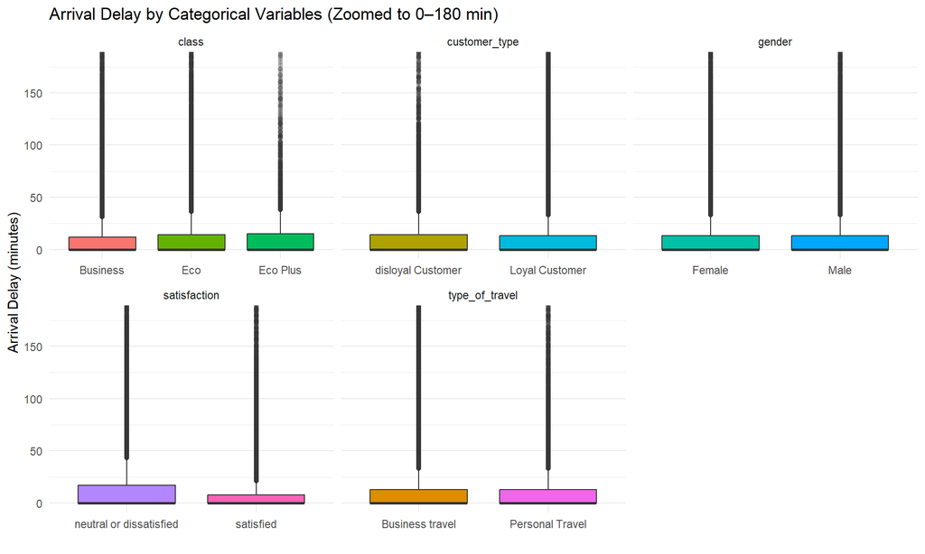

```r
train_clean %>%
  dplyr::select(arrival_delay_in_minutes, satisfaction, gender,
                customer_type, type_of_travel, class) %>%
  pivot_longer(-arrival_delay_in_minutes,
               names_to = "variable", values_to = "category") %>%
  ggplot(aes(x = category, y = arrival_delay_in_minutes, fill = category)) +
  geom_boxplot(outlier.alpha = 0.1) +
  facet_wrap(~ variable, scales = "free_x") +
  coord_cartesian(ylim = c(0, 180)) +
  theme_minimal() +
  theme(legend.position = "none") +
  labs(title = "Arrival Delay by Categorical Variables (Zoomed to 0–180 min)",
       y = "Arrival Delay (minutes)", x = "")
```

### 4.7.3 Imputation Justification Summary

Therefore, a simple linear regression `arrival_delay ~ departure_delay` is the most appropriate and parsimonious imputation model. Adding further predictors would contribute negligible information while increasing model complexity unnecessarily.

# 5 Missing Value Imputation

## 5.1 Imputation Model: Simple Linear Regression

Based on the EDA evidence, we fit a simple linear regression of arrival delay on departure delay using all complete cases in the **training set only**. Fitting on the training set prevents data leakage — the imputation model sees no information from the test set.

```r
train_reg <- train_clean %>%
  dplyr::select(departure_delay_in_minutes, arrival_delay_in_minutes) %>%
  na.omit()

# Fit the imputation model on complete training cases
delay_model <- lm(arrival_delay_in_minutes ~ departure_delay_in_minutes,
                  data = train_reg)
summary(delay_model)
```

```
##
## Call:
## lm(formula = arrival_delay_in_minutes ~ departure_delay_in_minutes,
##     data = train_reg)
##
## Residuals:
##     Min      1Q  Median      3Q     Max
## -47.707  -2.088  -0.722  -0.465 236.264
##
## Coefficients:
##                             Estimate Std. Error t value Pr(>|t|)
## (Intercept)                0.7224340  0.0335806   21.51   <2e-16 ***
## departure_delay_in_minutes 0.9802213  0.0008216 1193.01   <2e-16 ***
## ---
## Signif. codes:  0 '***' 0.001 '**' 0.01 '*' 0.05 '.' 0.1 ' ' 1
##
## Residual standard error: 10.08 on 103592 degrees of freedom
## Multiple R-squared:  0.9322, Adjusted R-squared:  0.9322
## F-statistic: 1.423e+06 on 1 and 103592 DF,  p-value: < 2.2e-16
```

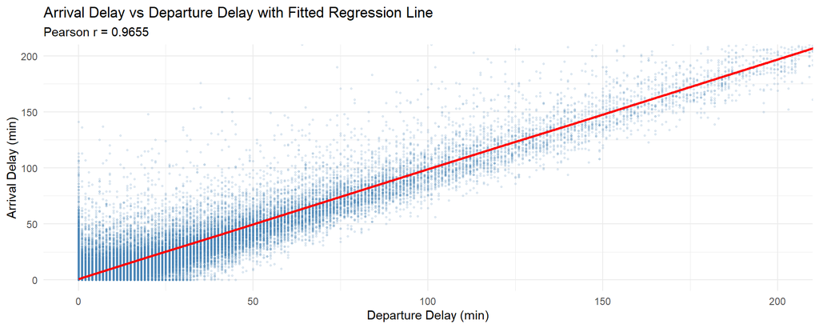

```r
ggplot(train_reg, aes(x = departure_delay_in_minutes, y = arrival_delay_in_minutes)) +
  geom_point(alpha = 0.15, color = "steelblue", size = 0.5) +
  geom_smooth(method = "lm", color = "red", se = TRUE) +
  coord_cartesian(xlim = c(0, 200), ylim = c(0, 200)) +
  labs(title = "Arrival Delay vs Departure Delay with Fitted Regression Line",
       subtitle = paste("Pearson r =",
                        round(cor(train_reg$departure_delay_in_minutes,
                                  train_reg$arrival_delay_in_minutes), 4)),
       x = "Departure Delay (min)", y = "Arrival Delay (min)") +
  theme_minimal()
```

## 5.2 Cross-Validation of Imputation Accuracy

```r
delay_model_glm <- glm(arrival_delay_in_minutes ~ departure_delay_in_minutes,
                       data = train_reg)
set.seed(123)
cv_result <- cv.glm(train_reg, delay_model_glm, K = 10)

cat("10-fold CV Mean Squared Error (imputation model):", round(cv_result$delta[1], 4), "\n")
```

```
## 10-fold CV Mean Squared Error (imputation model): 101.6165
```

```r
cat("Root MSE:", round(sqrt(cv_result$delta[1]), 2), "minutes\n")
```

```
## Root MSE: 10.08 minutes
```

## 5.3 Applying the Imputation

```r
# Preserve the versions with missing values for reference
train_with_na <- train_clean
test_with_na  <- test_clean
```

```r
# Impute using the model fitted on training data only (no leakage)
train_clean$arrival_delay_in_minutes[is.na(train_clean$arrival_delay_in_minutes)] <-
  predict(delay_model,
          newdata = train_clean[is.na(train_clean$arrival_delay_in_minutes), ])

test_clean$arrival_delay_in_minutes[is.na(test_clean$arrival_delay_in_minutes)] <-
  predict(delay_model,
          newdata = test_clean[is.na(test_clean$arrival_delay_in_minutes), ])

cat("Remaining NAs in train:", sum(is.na(train_clean$arrival_delay_in_minutes)), "\n")
```

```
## Remaining NAs in train: 0
```

```r
cat("Remaining NAs in test:", sum(is.na(test_clean$arrival_delay_in_minutes)), "\n")
```

```
## Remaining NAs in test: 0
```

After imputation both datasets are complete. We maintain three data versions throughout the analysis: `train_raw`/`test_raw` (original with index), `train_with_na`/`test_with_na` (cleaned but before imputation), and `train_clean`/`test_clean` (the working datasets after imputation).

# 6 Classification Modelling

We now proceed to classification. Our response variable is `satisfaction` (binary: “satisfied” vs “neutral or dissatisfied”). R modelling functions such as `glm()`, `lda()`, and `qda()` automatically handle categorical predictors by creating the appropriate dummy variables internally. For `class` (3 levels), R creates 2 dummies; for binary categoricals like `gender`, it creates 1 dummy.

```r
train <- train_clean
test  <- test_clean
train$satisfaction <- factor(train$satisfaction)
test$satisfaction <- factor(test$satisfaction)
```

## 6.1 Logistic Regression on Full Training Set

Following the approach from the course lab (Ch. 4), we fit a logistic regression using `glm()` with `family = binomial` on all available predictors. We fit on the **entire training set** to get the most reliable coefficient estimates and p-values for interpretation.

### 6.1.1 Model Fitting

```r
glm_full <- glm(satisfaction ~ ., data = train, family = binomial)
summary(glm_full)
```

```
##
## Call:
## glm(formula = satisfaction ~ ., family = binomial, data = train)
##
## Coefficients:
##                                     Estimate Std. Error  z value Pr(>|z|)
## (Intercept)                       -7.866e+00  7.864e-02 -100.026  < 2e-16 ***
## genderMale                         4.083e-02  1.946e-02    2.098  0.03593 *
## customer_typeLoyal Customer        2.036e+00  2.990e-02   68.099  < 2e-16 ***
## age                               -8.287e-03  7.096e-04  -11.679  < 2e-16 ***
## type_of_travelPersonal Travel     -2.721e+00  3.141e-02  -86.614  < 2e-16 ***
## classEco                          -7.368e-01  2.563e-02  -28.749  < 2e-16 ***
## classEco Plus                     -8.520e-01  4.146e-02  -20.548  < 2e-16 ***
## flight_distance                   -1.717e-05  1.130e-05   -1.519  0.12874
## inflight_wifi_service              3.946e-01  1.146e-02   34.443  < 2e-16 ***
## departure_arrival_time_convenient -1.248e-01  8.207e-03  -15.205  < 2e-16 ***
## ease_of_online_booking            -1.429e-01  1.133e-02  -12.616  < 2e-16 ***
## gate_location                      2.927e-02  9.159e-03    3.195  0.00140 **
## food_and_drink                    -2.764e-02  1.067e-02   -2.591  0.00957 **
## online_boarding                    6.123e-01  1.023e-02   59.851  < 2e-16 ***
## seat_comfort                       6.662e-02  1.117e-02    5.967 2.42e-09 ***
## inflight_entertainment             6.413e-02  1.425e-02    4.502 6.73e-06 ***
## on_board_service                   3.014e-01  1.017e-02   29.627  < 2e-16 ***
## leg_room_service                   2.530e-01  8.524e-03   29.686  < 2e-16 ***
## baggage_handling                   1.344e-01  1.142e-02   11.765  < 2e-16 ***
## checkin_service                    3.238e-01  8.554e-03   37.860  < 2e-16 ***
## inflight_service                   1.199e-01  1.203e-02    9.969  < 2e-16 ***
## cleanliness                        2.232e-01  1.208e-02   18.472  < 2e-16 ***
## departure_delay_in_minutes         4.782e-03  9.878e-04    4.841 1.29e-06 ***
## arrival_delay_in_minutes          -9.411e-03  9.742e-04   -9.660  < 2e-16 ***
## ---
## Signif. codes:  0 '***' 0.001 '**' 0.01 '*' 0.05 '.' 0.1 ' ' 1
##
## (Dispersion parameter for binomial family taken to be 1)
##
##     Null deviance: 142189  on 103903  degrees of freedom
## Residual deviance:  69383  on 103880  degrees of freedom
## AIC: 69431
##
## Number of Fisher Scoring iterations: 6
```

### 6.1.2 Coefficient Interpretation

```r
coef_table <- summary(glm_full)$coefficients %>%
  as.data.frame() %>%
  rownames_to_column("Variable") %>%
  rename(Estimate = Estimate, SE = `Std. Error`,
         z_value = `z value`, p_value = `Pr(>|z|)`) %>%
  mutate(
    Odds_Ratio = round(exp(Estimate), 4),
    Significant = ifelse(p_value < 0.05, "Yes", "No"),
    p_value = signif(p_value, 4)
  ) %>%
  arrange(p_value)

coef_table %>%
  kable(digits = 4) %>%
  kable_styling(bootstrap_options = "striped", full_width = FALSE) %>%
  scroll_box(height = "400px")
```

| Variable | Estimate | SE | z_value | p_value | Odds_Ratio | Significant |
| --- | --- | --- | --- | --- | --- | --- |
| (Intercept) | -7.8663 | 0.0786 | -100.0262 | 0.0000 | 0.0004 | Yes |
| customer_typeLoyal Customer | 2.0362 | 0.0299 | 68.0995 | 0.0000 | 7.6614 | Yes |
| type_of_travelPersonal Travel | -2.7205 | 0.0314 | -86.6139 | 0.0000 | 0.0658 | Yes |
| online_boarding | 0.6123 | 0.0102 | 59.8511 | 0.0000 | 1.8447 | Yes |
| checkin_service | 0.3238 | 0.0086 | 37.8602 | 0.0000 | 1.3824 | Yes |
| inflight_wifi_service | 0.3946 | 0.0115 | 34.4434 | 0.0000 | 1.4838 | Yes |
| leg_room_service | 0.2530 | 0.0085 | 29.6862 | 0.0000 | 1.2879 | Yes |
| on_board_service | 0.3014 | 0.0102 | 29.6269 | 0.0000 | 1.3518 | Yes |
| classEco | -0.7368 | 0.0256 | -28.7494 | 0.0000 | 0.4787 | Yes |
| classEco Plus | -0.8520 | 0.0415 | -20.5482 | 0.0000 | 0.4266 | Yes |
| cleanliness | 0.2232 | 0.0121 | 18.4722 | 0.0000 | 1.2501 | Yes |
| departure_arrival_time_convenient | -0.1248 | 0.0082 | -15.2052 | 0.0000 | 0.8827 | Yes |
| ease_of_online_booking | -0.1429 | 0.0113 | -12.6156 | 0.0000 | 0.8668 | Yes |
| baggage_handling | 0.1344 | 0.0114 | 11.7652 | 0.0000 | 1.1438 | Yes |
| age | -0.0083 | 0.0007 | -11.6785 | 0.0000 | 0.9917 | Yes |
| inflight_service | 0.1199 | 0.0120 | 9.9693 | 0.0000 | 1.1274 | Yes |
| arrival_delay_in_minutes | -0.0094 | 0.0010 | -9.6601 | 0.0000 | 0.9906 | Yes |
| seat_comfort | 0.0666 | 0.0112 | 5.9667 | 0.0000 | 1.0689 | Yes |
| departure_delay_in_minutes | 0.0048 | 0.0010 | 4.8409 | 0.0000 | 1.0048 | Yes |
| inflight_entertainment | 0.0641 | 0.0142 | 4.5020 | 0.0000 | 1.0662 | Yes |
| gate_location | 0.0293 | 0.0092 | 3.1954 | 0.0014 | 1.0297 | Yes |
| food_and_drink | -0.0276 | 0.0107 | -2.5912 | 0.0096 | 0.9727 | Yes |
| genderMale | 0.0408 | 0.0195 | 2.0977 | 0.0359 | 1.0417 | Yes |
| flight_distance | 0.0000 | 0.0000 | -1.5191 | 0.1287 | 1.0000 | No |

In logistic regression, the coefficients are on the log-odds scale: a positive coefficient means that increasing that predictor raises the log-odds (and therefore the probability) of the positive class (“satisfied”), while a negative coefficient decreases it. The **odds ratio** (`exp(Estimate)`) gives a more intuitive interpretation: an odds ratio greater than 1 means the predictor increases the odds of satisfaction, less than 1 decreases them.

## 6.2 Feature Selection via Stepwise Methods

The full model includes all 23 predictors, but the coefficient table suggests that several variables contribute little predictive value. Stepwise selection iteratively adds or removes variables guided by an information criterion, providing a principled way to identify a parsimonious model.

**AIC** (Akaike Information Criterion): AIC = −2 × log-likelihood + 2k, where k is the number of parameters. Balances fit against complexity with a moderate parsimony penalty.

**BIC** (Bayesian Information Criterion): BIC = −2 × log-likelihood + k × log(n). With n ≈ 103,000, the BIC penalty is much larger than AIC (log(103000) ≈ 11.5 vs. 2), so BIC strongly favours smaller models.

### 6.2.1 Forward Stepwise Selection (AIC)

Starting from the null (intercept-only) model, we add one variable at a time, choosing at each step the variable that produces the largest reduction in AIC.

```r
glm_null <- glm(satisfaction ~ 1, data = train, family = binomial)

step_fwd_aic <- step(glm_null,
                     scope = list(lower = glm_null, upper = glm_full),
                     direction = "forward", trace = FALSE)
```

```r
cat("Forward AIC — Number of predictors selected:", length(coef(step_fwd_aic)) - 1, "\n")
```

```
## Forward AIC — Number of predictors selected: 23
```

```r
cat("AIC:", round(AIC(step_fwd_aic), 2), "\n\n")
```

```
## AIC: 69430.92
```

```r
cat("Selected variables:\n")
```

```
## Selected variables:
```

```r
cat(names(coef(step_fwd_aic))[-1], sep = "\n")
```

```
## online_boarding
## type_of_travelPersonal Travel
## on_board_service
## customer_typeLoyal Customer
## checkin_service
## inflight_entertainment
## leg_room_service
## classEco
## classEco Plus
## inflight_wifi_service
## departure_arrival_time_convenient
## cleanliness
## arrival_delay_in_minutes
## baggage_handling
## ease_of_online_booking
## age
## inflight_service
## seat_comfort
## departure_delay_in_minutes
## gate_location
## food_and_drink
## genderMale
## flight_distance
```

### 6.2.2 Backward Stepwise Selection (AIC)

Starting from the full model, we remove one variable at a time, dropping the variable whose removal causes the smallest increase in AIC (or the largest decrease).

```r
step_bwd_aic <- step(glm_full, direction = "backward", trace = FALSE)
```

```r
cat("Backward AIC — Number of predictors selected:", length(coef(step_bwd_aic)) - 1, "\n")
```

```
## Backward AIC — Number of predictors selected: 23
```

```r
cat("AIC:", round(AIC(step_bwd_aic), 2), "\n\n")
```

```
## AIC: 69430.92
```

```r
cat("Selected variables:\n")
```

```
## Selected variables:
```

```r
cat(names(coef(step_bwd_aic))[-1], sep = "\n")
```

```
## genderMale
## customer_typeLoyal Customer
## age
## type_of_travelPersonal Travel
## classEco
## classEco Plus
## flight_distance
## inflight_wifi_service
## departure_arrival_time_convenient
## ease_of_online_booking
## gate_location
## food_and_drink
## online_boarding
## seat_comfort
## inflight_entertainment
## on_board_service
## leg_room_service
## baggage_handling
## checkin_service
## inflight_service
## cleanliness
## departure_delay_in_minutes
## arrival_delay_in_minutes
```

### 6.2.3 Forward Stepwise Selection (BIC)

Same procedure as forward AIC, but with the stricter BIC penalty (`k = log(n)`), which favours more parsimonious models.

```r
n_train <- nrow(train)

step_fwd_bic <- step(glm_null,
                     scope = list(lower = glm_null, upper = glm_full),
                     direction = "forward",
                     k = log(n_train), trace = FALSE)
```

```r
cat("Forward BIC — Number of predictors selected:", length(coef(step_fwd_bic)) - 1, "\n")
```

```
## Forward BIC — Number of predictors selected: 19
```

```r
cat("BIC:", round(BIC(step_fwd_bic), 2), "\n\n")
```

```
## BIC: 69637.5
```

```r
cat("Selected variables:\n")
```

```
## Selected variables:
```

```r
cat(names(coef(step_fwd_bic))[-1], sep = "\n")
```

```
## online_boarding
## type_of_travelPersonal Travel
## on_board_service
## customer_typeLoyal Customer
## checkin_service
## inflight_entertainment
## leg_room_service
## classEco
## classEco Plus
## inflight_wifi_service
## departure_arrival_time_convenient
## cleanliness
## arrival_delay_in_minutes
## baggage_handling
## ease_of_online_booking
## age
## inflight_service
## seat_comfort
## departure_delay_in_minutes
```

### 6.2.4 Backward Stepwise Selection (BIC)

```r
step_bwd_bic <- step(glm_full, direction = "backward",
                     k = log(n_train), trace = FALSE)
```

```r
cat("Backward BIC — Number of predictors selected:", length(coef(step_bwd_bic)) - 1, "\n")
```

```
## Backward BIC — Number of predictors selected: 19
```

```r
cat("BIC:", round(BIC(step_bwd_bic), 2), "\n\n")
```

```
## BIC: 69637.5
```

```r
cat("Selected variables:\n")
```

```
## Selected variables:
```

```r
cat(names(coef(step_bwd_bic))[-1], sep = "\n")
```

```
## customer_typeLoyal Customer
## age
## type_of_travelPersonal Travel
## classEco
## classEco Plus
## inflight_wifi_service
## departure_arrival_time_convenient
## ease_of_online_booking
## online_boarding
## seat_comfort
## inflight_entertainment
## on_board_service
## leg_room_service
## baggage_handling
## checkin_service
## inflight_service
## cleanliness
## departure_delay_in_minutes
## arrival_delay_in_minutes
```

### 6.2.5 AIC and BIC along the Forward Selection Path

To visualise how the information criteria evolve as variables are added, we extract the forward AIC selection path and compute both AIC and BIC at each step.

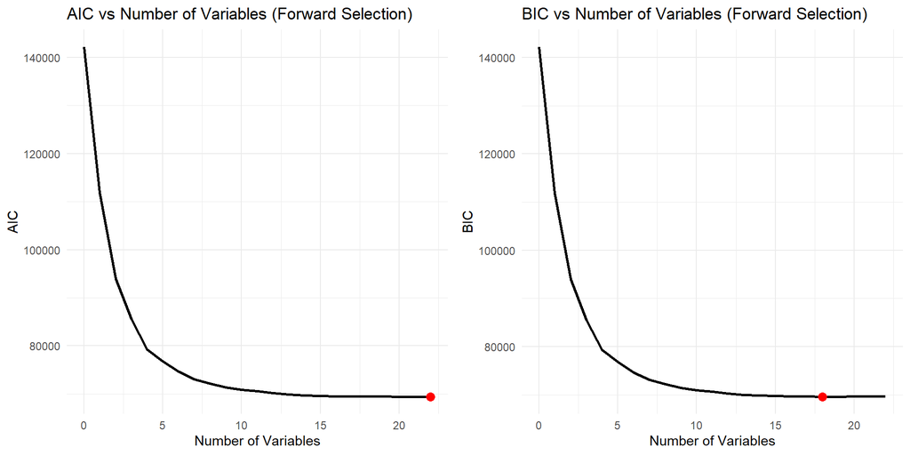

```r
# Re-run forward selection, keeping track of each step's model
# We use the AIC path and compute BIC from the deviance at each step
fwd_anova <- step_fwd_aic$anova

# The anova table from step() records the AIC at each step
# We need to compute BIC as well: BIC = Deviance + k * log(n)
# Number of parameters at each step (row 1 = intercept only = 1 param, etc.)
n_params  <- seq_len(nrow(fwd_anova))
aic_path  <- fwd_anova$AIC
dev_path  <- fwd_anova$`Resid. Dev`
bic_path  <- dev_path + n_params * log(n_train)
n_vars    <- 0:(nrow(fwd_anova) - 1)

path_df <- data.frame(
  n_vars   = n_vars,
  AIC      = aic_path,
  BIC      = bic_path
)

# AIC plot
p_aic <- ggplot(path_df, aes(x = n_vars, y = AIC)) +
  geom_line(linewidth = 1) +
  geom_point(data = path_df[which.min(path_df$AIC), ],
             aes(x = n_vars, y = AIC), color = "red", size = 3) +
  labs(title = "AIC vs Number of Variables (Forward Selection)",
       x = "Number of Variables", y = "AIC") +
  theme_minimal()

# BIC plot
p_bic <- ggplot(path_df, aes(x = n_vars, y = BIC)) +
  geom_line(linewidth = 1) +
  geom_point(data = path_df[which.min(path_df$BIC), ],
             aes(x = n_vars, y = BIC), color = "red", size = 3) +
  labs(title = "BIC vs Number of Variables (Forward Selection)",
       x = "Number of Variables", y = "BIC") +
  theme_minimal()

grid.arrange(p_aic, p_bic, ncol = 2)
```

```r
cat("Optimal number of variables by AIC:", path_df$n_vars[which.min(path_df$AIC)], "\n")
```

```
## Optimal number of variables by AIC: 22
```

```r
cat("Optimal number of variables by BIC:", path_df$n_vars[which.min(path_df$BIC)], "\n")
```

```
## Optimal number of variables by BIC: 18
```

### 6.2.6 Summary of Stepwise Feature Selection

```r
summary_df <- data.frame(
  Method          = c("Full Model", "Forward AIC", "Backward AIC",
                      "Forward BIC", "Backward BIC"),
  N_variables     = c(length(coef(glm_full)) - 1,
                      length(coef(step_fwd_aic)) - 1,
                      length(coef(step_bwd_aic)) - 1,
                      length(coef(step_fwd_bic)) - 1,
                      length(coef(step_bwd_bic)) - 1),
  AIC             = round(c(AIC(glm_full), AIC(step_fwd_aic), AIC(step_bwd_aic),
                            AIC(step_fwd_bic), AIC(step_bwd_bic)), 2),
  BIC             = round(c(BIC(glm_full), BIC(step_fwd_aic), BIC(step_bwd_aic),
                            BIC(step_fwd_bic), BIC(step_bwd_bic)), 2)
)

summary_df %>%
  kable() %>%
  kable_styling(bootstrap_options = "striped", full_width = FALSE)
```

| Method | N_variables | AIC | BIC |
| --- | --- | --- | --- |
| Full Model | 23 | 69430.92 | 69660.15 |
| Forward AIC | 23 | 69430.92 | 69660.15 |
| Backward AIC | 23 | 69430.92 | 69660.15 |
| Forward BIC | 19 | 69446.48 | 69637.50 |
| Backward BIC | 19 | 69446.48 | 69637.50 |